# Supervised learning: Regression 2

# Regularisation with glmnet

`glmnet` is a package that implements efficient (quick!) algorithms for LASSO and ridge regression, among other things.

10. **Read through the help file of `glmnet`. We are going to perform a linear regression with normal (gaussian) error terms. What format should our data be in?**

```r
# We need to input a predictor matrix x and a response (outcome) variable y,
# as well as a family = "gaussian"
```

Again, we will try to predict baseball salary, this time using all the available variables and using the LASSO penalty to perform subset selection. For this, we first need to generate an input matrix.

11. **First generate the input matrix using (a variation on) the following code. Remember that the “.” in a formula means “all available variables”. Make sure to check that this `x_train` looks like what you would expect.**

```r
x_train <- model.matrix(Salary ~ ., data = baseball_train %>% select(-split))
head(x_train)
```

```
##                   (Intercept) AtBat Hits HmRun Runs RBI Walks Years CAtBat
## -Alan Ashby                 1   315   81     7   24  38    39    14   3449
## -Andre Dawson               1   496  141    20   65  78    37    11   5628
## -Andres Galarraga           1   321   87    10   39  42    30     2    396
## -Alfredo Griffin            1   594  169     4   74  51    35    11   4408
## -Al Newman                  1   185   37     1   23   8    21     2    214
## -Argenis Salazar            1   298   73     0   24  24     7     3    509
##                   CHits CHmRun CRuns CRBI CWalks LeagueN DivisionW PutOuts
## -Alan Ashby         835     69   321  414    375       1         1     632
## -Andre Dawson      1575    225   828  838    354       1         0     200
## -Andres Galarraga   101     12    48   46     33       1         0     805
## -Alfredo Griffin   1133     19   501  336    194       0         1     282
## -Al Newman           42      1    30    9     24       1         0      76
## -Argenis Salazar    108      0    41   37     12       0         1     121
##                   Assists Errors NewLeagueN
## -Alan Ashby            43     10          1
## -Andre Dawson          11      3          1
## -Andres Galarraga      40      4          1
## -Alfredo Griffin      421     25          0
## -Al Newman            127      7          0
## -Argenis Salazar      283      9          0
```

The `model.matrix()` function takes a dataset and a formula and outputs the predictor matrix where the categorical variables have been correctly transformed into dummy variables, and it adds an intercept. It is used internally by the `lm()` function as well!

12. **Using `glmnet()`, perform a LASSO regression with the generated `x_train` as the predictor matrix and `Salary` as the response variable. Set the `lambda` parameter of the penalty to 15. NB: Remove the intercept column from the `x_matrix` – `glmnet` adds an intercept internally.**

```r
result <- glmnet(x      = x_train[, -1],          # X matrix without intercept
                 y      = baseball_train$Salary,  # Salary as response
                 family = "gaussian",             # Normally distributed errors
                 alpha  = 1,                      # LASSO penalty
                 lambda = 15)                     # Penalty value
```

13. **The coefficients for the variables are in the `beta` element of the list generated by the `glmnet()` function. Which variables have been selected? You may use the `coef()` function.**

```r
rownames(coef(result))[which(coef(result) != 0)]
```

```
##  [1] "(Intercept)" "Hits"        "Runs"        "Walks"       "CHmRun"
##  [6] "CRuns"       "CRBI"        "DivisionW"   "PutOuts"     "Assists"
## [11] "NewLeagueN"
```

14. **Create a predicted versus observed plot for the model you generated with the `baseball_valid` data. Use the `predict()` function for this! What is the MSE on the validation set?**

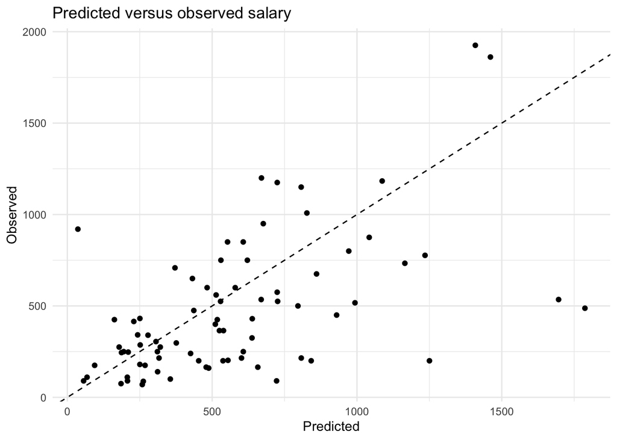

```r
x_valid <- model.matrix(Salary ~ ., data = baseball_valid %>% select(-split))[, -1]
y_pred <- as.numeric(predict(result, newx = x_valid))

tibble(Predicted = y_pred, Observed = baseball_valid$Salary) %>%
  ggplot(aes(x = Predicted, y = Observed)) +
  geom_point() +
  geom_abline(slope = 1, intercept = 0, lty = 2) +
  theme_minimal() +
  labs(title = "Predicted versus observed salary")
```

```r
mse(baseball_valid$Salary, y_pred)
```

```
## [1] 131955.2
```

# Tuning lambda

Like many methods of analysis, regularised regression has a *tuning parameter*. In the previous section, we’ve set this parameter to 15. The `lambda` parameter changes the strength of the shrinkage in `glmnet()`. Changing the tuning parameter will change the predictions, and thus the MSE. In this section, we will select the tuning parameter based on out-of-sample MSE.

15. **Fit a LASSO regression model on the same data as before, but now do not enter a specific `lambda` value. What is different about the object that is generated? Hint: use the `coef()` and `plot()` methods on the resulting object.**

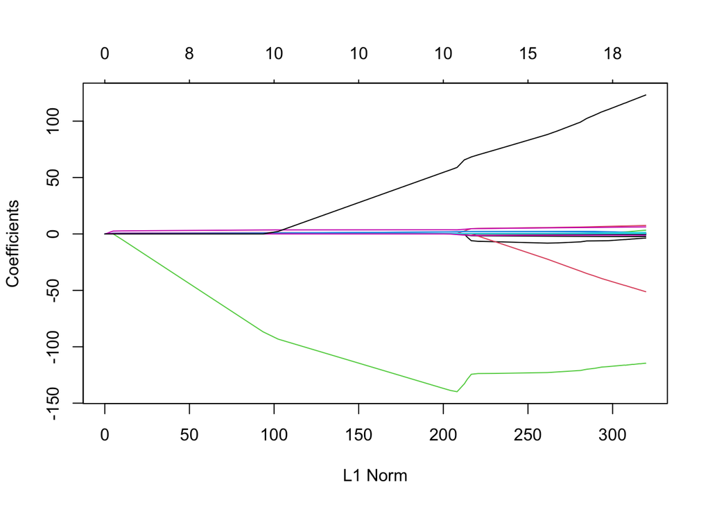

```r
result_nolambda <- glmnet(x = x_train[, -1], y = baseball_train$Salary,
                          family = "gaussian", alpha  = 1)

# This object contains sets of coefficients for different values of lambda,
# i.e., different models ranging from an intercept-only model (very high
# lambda) to almost no shrinkage (very low lambda).

plot(result_nolambda)
```

For deciding which value of lambda to choose, we could work similarly to what we have don in the best subset selection section before. However, the `glmnet` package includes another method for this task: cross validation.

16. **Use the `cv.glmnet` function to determine the `lambda` value for which the out-of-sample MSE is lowest using 15-fold cross validation. As your dataset, you may use the training and validation sets bound together with bind_rows(). What is the best lambda value?**

```r
x_cv <- model.matrix(Salary ~ ., bind_rows(baseball_train, baseball_valid)[, -21])[, -1]
result_cv <- cv.glmnet(x = x_cv, y = c(baseball_train$Salary, baseball_valid$Salary), nfolds = 15)
best_lambda <- result_cv$lambda.min
best_lambda
```

```
## [1] 1.774744
```

17. **Try out the plot() method on this object. What do you see? What does this tell you about the bias-variance tradeoff?**

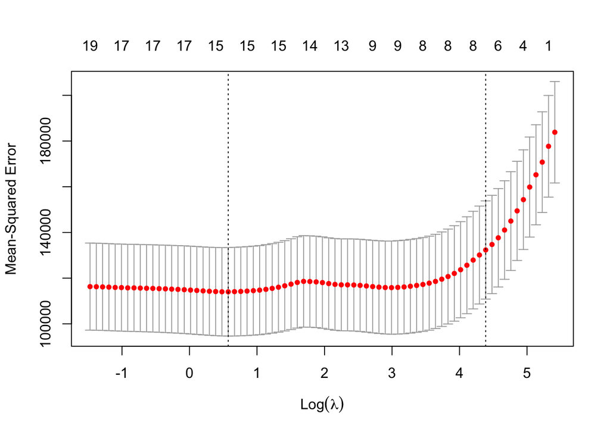

```r
plot(result_cv)
```

```r
# the MSE is high with very small values of lambda (no shrinkage) and
# with very large values of lambda (intercept-only model).

# introducing a bit of bias lowers the variance relatively strongly
# (fewer variables in the model) and therefore the MSE is reduced.
```

18. **Use the `predict()` method directly on the object you just created to predict new salaries for the baseball players in the `baseball_test` dataset using the best lambda value you just created (hint: you need to use the `s` argument, look at `?predict.cv.glmnet` for help). Create another predicted-observed scatter plot.**

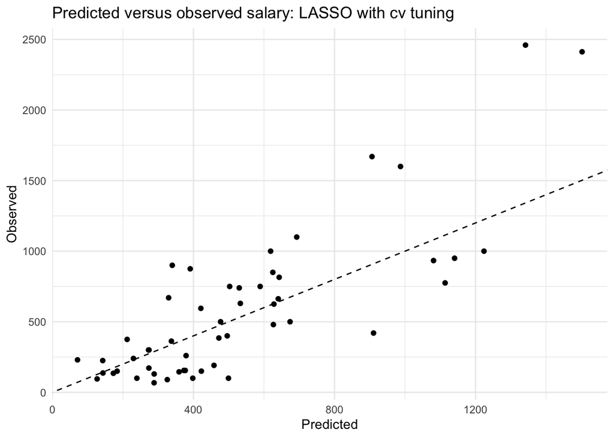

```r
x_test <- model.matrix(Salary ~ ., data = baseball_test %>% select(-split))[, -1]
y_pred <- as.numeric(predict(result_cv, newx = x_test, s = best_lambda))

tibble(Predicted = y_pred, Observed = baseball_test$Salary) %>%
  ggplot(aes(x = Predicted, y = Observed)) +
  geom_point() +
  geom_abline(slope = 1, intercept = 0, lty = 2) +
  theme_minimal() +
  labs(title = "Predicted versus observed salary: LASSO with cv tuning")
```

```r
mse(baseball_test$Salary, y_pred)
```

```
## [1] 107147.6
```

# Exercise: method comparison

19. **Create a bar plot comparing the test set (baseball_test) MSE of (a) linear regression with all variables, (b) the best subset selection regression model we created, (c) LASSO with lambda set to 50, and (d) LASSO with cross-validated lambda. As training dataset, use the rows in both the `baseball_train` and `baseball_valid`**

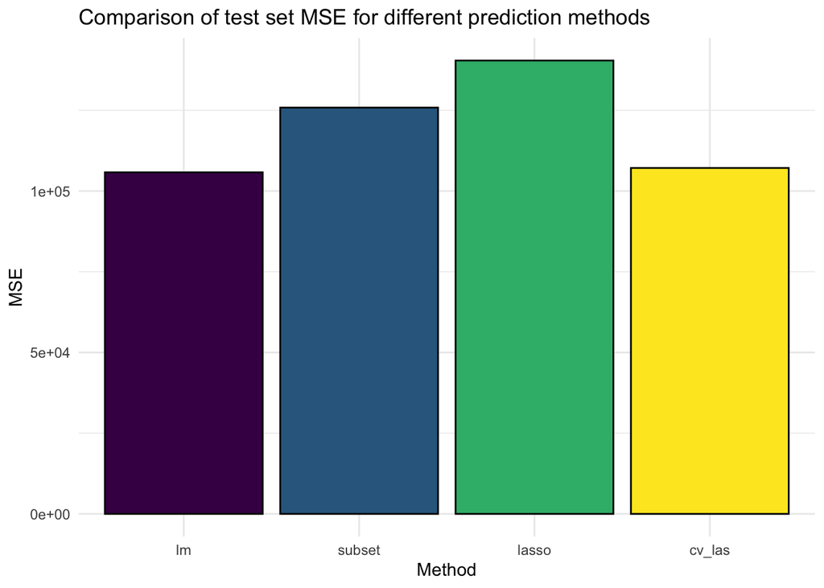

```r
# create this new training dataset
train_data <- bind_rows(baseball_train, baseball_valid)[, -21]

# generate predictions from the models
y_pred_ols <- predict(lm(Salary ~ ., data = train_data), newdata = baseball_test)
y_pred_sub <- predict(lm(Salary ~ Runs + CHits + Division + PutOuts, data = train_data),
                      newdata = baseball_test)
# these two use x_cv and x_test from the previous exercises
y_pred_las <- as.numeric(predict(glmnet(x_cv, train_data$Salary, lambda = 50), newx = x_test))
y_pred_cv  <- as.numeric(predict(result_cv, newx = x_test, s = best_lambda))

# Calculate MSEs
mses <- c(
  mse(baseball_test$Salary, y_pred_ols),
  mse(baseball_test$Salary, y_pred_sub),
  mse(baseball_test$Salary, y_pred_las),
  mse(baseball_test$Salary, y_pred_cv)
)

# Create a plot
tibble(Method = as_factor(c("lm", "subset", "lasso", "cv_las")), MSE = mses) %>%
  ggplot(aes(x = Method, y = MSE, fill = Method)) +
  geom_bar(stat = "identity", col = "black") +
  theme_minimal() +
  theme(legend.position = "none") +
  labs(title = "Comparison of test set MSE for different prediction methods") +
  scale_fill_viridis_d() # different colour scale
```